# wrangling

Import libraries.

```python
import io, os, sys, types, time, datetime, math, random, requests, subprocess, tempfile
```

```python
import pandas as pd
import matplotlib.pyplot as plt
import numpy as np
import statsmodels.api as sm
import statsmodels.formula.api as smf
from statsmodels.stats.diagnostic import het_breuschpagan
from statsmodels.stats.diagnostic import het_white
from statsmodels.stats.outliers_influence import variance_inflation_factor
import seaborn as sns
from sklearn.ensemble import RandomForestClassifier, GradientBoostingClassifier
```

Set working directory.

```python
os.getcwd()
os.chdir("/Users/bvelasq6/Box Sync/CEE Educational Analytics/ATOG Analysis")
os.getcwd()
```

```
'/Users/bvelasq6/Box Sync/CEE Educational Analytics/ATOG Analysis'
```

Import relevant files

```python
admissions = pd.read_csv("Data/admissions.csv",low_memory=False)
courses = pd.read_csv("Data/courses.csv",low_memory = False)
ap_tests = pd.read_csv("Data/ap_tests.csv",low_memory= False)
students = pd.read_csv("/Users/bvelasq6/Box Sync/CEE Core Data/students.csv",low_memory=False)
students = students[students.PIDM.isin (admissions["PIDM"])]
```

```python
list(students)
student_subset = ["PIDM","ADMIT_LEVEL","GENDER","ETHN_CODE",
                  "IS_URM","FIRST_TERM_GPA","FIRST_TERM_MAJOR_1",
                  "FIRST_TERM_MAJOR_2",
                  "FIRST_TERM_MAJOR_3",
                  "ANY_FIRST_TERM_MAJOR_IS_STEM",
                  'NUM_MAJOR_CHANGES',
 'NUM_WLD_MAT_RMED',
 'NUM_WLD_MAT_PREP',
 'NUM_WLD_MAT_CONC',
 'NUM_WLD_CHE_PREP',
 'NUM_WLD_CHE_CONC',
 'NUM_WLD_PHY_PREP',
 'NUM_WLD_PHY_CONC',
 'NUM_WLD_ENGLISH',
 'NUM_STEM_CRSE',
'STARTED_INTERNATIONAL',
                   'FIRST_GENERATION',
 'LOW_INCOME',
                   'TRIPLE',
                   'NO_TRIPLE',
                    'NUM_TERM_NOT_GS',
 'FIRST_TERM_NOT_GS'
]
students = students[student_subset]
```

```python
admissions.describe()
```

|  | PIDM | TERM | CRAP | CRAPOLD | HSCODE | LSTYPE | ATOG | ATOGA | ATOGB | ATOGC | ... | GPAR | GPAT | UNWEIGHTED_GPA | SAT_TOTAL_OFFICIAL | SATM_SECTION_OFFICIAL | SAT_WR_SECTION_OFFICIAL | SAT_OR_ACT_OFFICIAL | SATRM_OFFICIAL | SATRW_OFFICIAL | SATRR_OFFICIAL |
| --- | --- | --- | --- | --- | --- | --- | --- | --- | --- | --- | --- | --- | --- | --- | --- | --- | --- | --- | --- | --- | --- |
| count | 2.399300e+04 | 23993.000000 | 0.0 | 0.0 | 23983.000000 | 23993.000000 | 23993.000000 | 23993.00000 | 23993.000000 | 23993.000000 | ... | 1885.000000 | 0.0 | 22615.000000 | 16514.000000 | 16514.000000 | 16514.000000 | 23917.000000 | 16514.000000 | 16514.000000 | 16514.000000 |
| mean | 3.273453e+06 | 201762.312716 | NaN | NaN | 174395.308302 | 1.167507 | 51.490447 | 7.25149 | 8.517734 | 11.270079 | ... | 3.848782 | NaN | 3.758421 | 1267.963546 | 650.127770 | 619.405353 | 1278.929632 | 32.508175 | 31.357515 | 30.547414 |
| std | 1.246689e+05 | 110.760618 | NaN | NaN | 273621.973418 | 0.388211 | 11.507415 | 3.64118 | 2.052259 | 3.547796 | ... | 0.236052 | NaN | 0.222113 | 154.925591 | 97.949989 | 77.888380 | 156.177072 | 4.891018 | 4.180286 | 4.208844 |
| min | 2.455146e+06 | 201610.000000 | NaN | NaN | 10806.000000 | 1.000000 | 0.000000 | 0.00000 | 0.000000 | 0.000000 | ... | 2.500000 | NaN | 0.000000 | 630.000000 | 0.000000 | 310.000000 | 630.000000 | 15.000000 | 13.000000 | 12.000000 |
| 25% | 3.177790e+06 | 201710.000000 | NaN | NaN | 51412.000000 | 1.000000 | 45.000000 | 5.00000 | 8.000000 | 10.000000 | ... | 3.720000 | NaN | 3.650000 | 1160.000000 | 580.000000 | 570.000000 | 1180.000000 | 29.000000 | 29.000000 | 28.000000 |
| 50% | 3.284463e+06 | 201810.000000 | NaN | NaN | 52980.000000 | 1.000000 | 49.000000 | 6.00000 | 8.000000 | 10.000000 | ... | 3.890000 | NaN | 3.800000 | 1290.000000 | 660.000000 | 620.000000 | 1300.000000 | 33.000000 | 32.000000 | 31.000000 |
| 75% | 3.374587e+06 | 201810.000000 | NaN | NaN | 54284.000000 | 1.000000 | 54.000000 | 8.00000 | 8.000000 | 12.000000 | ... | 4.000000 | NaN | 3.920000 | 1380.000000 | 730.000000 | 680.000000 | 1400.000000 | 36.500000 | 34.000000 | 33.000000 |
| max | 3.502799e+06 | 201910.000000 | NaN | NaN | 999999.000000 | 7.000000 | 240.000000 | 64.00000 | 50.000000 | 99.000000 | ... | 4.500000 | NaN | 4.000000 | 1600.000000 | 800.000000 | 800.000000 | 1600.000000 | 40.000000 | 40.000000 | 40.000000 |

8 rows × 93 columns

Pivot and rename the AP test so it's easier to work with.

```python
test_sub = ["APST","APMA","APBI","APMB","APCH","APPM","APCA","APP1","APPB","APPC","APP2"]
ap_tests_unique = ap_tests[ap_tests.TEST.isin (test_sub)].groupby(['TEST','DESCRIPTION']).size().reset_index().rename(columns={0:'count'})
ap_test_sub = ap_tests[ap_tests.TEST.isin (test_sub)]
ap_test_sub = ap_test_sub.groupby(['PIDM','TEST'],as_index=False)['SCORE'].max()
ap_test_sub = ap_test_sub.pivot(index='PIDM',columns='TEST',values='SCORE')
ap_test_sub = ap_test_sub.rename(columns={"APBI": "AP_Bio",
                            "APCA": "AP_CS",
                            "APCH":"AP_Chemistry",
                            "APMA":"AP_Calculus_AB",
                            "APMB":"AP_Calculus_BC",
                            "APP1": "AP_Physics_1",
                           "APP2": "AP_Physics_2",
                           "APPB": "AP_Physics_B",
                           "APPC": "AP_Physics_C_EM",
                           "APPM": "AP_Physics_C_Mech",
                           "APST": "AP_Stats"})
```

Summary stats of the AP tests we are interested in.

```python
#ap_test_sub.head(n=3)
# ap_tests_unique
ap_test_sub.describe()
#ap_tests.drop_duplicates(['TEST','DESCRIPTION'])[['TEST','DESCRIPTION']]
```

| TEST | AP_Bio | AP_CS | AP_Chemistry | AP_Calculus_AB | AP_Calculus_BC | AP_Physics_1 | AP_Physics_2 | AP_Physics_B | AP_Physics_C_EM | AP_Physics_C_Mech | AP_Stats |
| --- | --- | --- | --- | --- | --- | --- | --- | --- | --- | --- | --- |
| count | 393.000000 | 43.000000 | 588.000000 | 395.000000 | 173.000000 | 132.000000 | 22.000000 | 10.000000 | 13.000000 | 39.000000 | 106.000000 |
| mean | 3.587786 | 3.906977 | 3.602041 | 4.298734 | 4.375723 | 3.613636 | 3.727273 | 3.900000 | 4.461538 | 4.205128 | 3.811321 |
| std | 0.653135 | 0.781145 | 0.715939 | 0.807247 | 0.809026 | 0.727305 | 0.702500 | 0.994429 | 0.776250 | 0.695076 | 0.769826 |
| min | 3.000000 | 3.000000 | 3.000000 | 3.000000 | 3.000000 | 3.000000 | 3.000000 | 3.000000 | 3.000000 | 3.000000 | 3.000000 |
| 25% | 3.000000 | 3.000000 | 3.000000 | 4.000000 | 4.000000 | 3.000000 | 3.000000 | 3.000000 | 4.000000 | 4.000000 | 3.000000 |
| 50% | 3.000000 | 4.000000 | 3.000000 | 5.000000 | 5.000000 | 3.000000 | 4.000000 | 3.500000 | 5.000000 | 4.000000 | 4.000000 |
| 75% | 4.000000 | 4.500000 | 4.000000 | 5.000000 | 5.000000 | 4.000000 | 4.000000 | 5.000000 | 5.000000 | 5.000000 | 4.000000 |
| max | 5.000000 | 5.000000 | 5.000000 | 5.000000 | 5.000000 | 5.000000 | 5.000000 | 5.000000 | 5.000000 | 5.000000 | 5.000000 |

Note: Is it really that rare for students to take AP tests? How many students are in the data frame?

The next two blocks of code are used to create dummy variables. Currently these are not being used, but in the future they might be useful.

```python
# ap_test_sub = pd.get_dummies(ap_test_sub, sparse=True, columns =['AP_Bio',
#  'AP_CS',
#  'AP_Chemistry',
#  'AP_Calculus_AB',
#  'AP_Calculus_BC',
#  'AP_Physics_1',
#  'AP_Physics_2',
#  'AP_Physics_B',
#  'AP_Physics_C_EM',
#  'AP_Physics_C_Mech',
#  'AP_Stats'])
# ap_test_sub.head(3)
# ap_test_sub.columns.isin(['AP_Bio',
#  'AP_CS',
#  'AP_Chemistry',
#  'AP_Calculus_AB',
#  'AP_Calculus_BC',
#  'AP_Physics_1',
#  'AP_Physics_2',
#  'AP_Physics_B',
#  'AP_Physics_C_EM',
#  'AP_Physics_C_Mech.',
#  'AP_Stats'])
```

```python
# ap_test_sub['no_AP_Bio_1'] = np.where(
#     (ap_test_sub['AP_Bio_3.0'] == 0 ) &
#     (ap_test_sub['AP_Bio_4.0'] == 0 ) &
#     (ap_test_sub['AP_Bio_5.0'] == 0 ),
#                                     1, 0)

# ap_test_sub['no_AP_CS'] = np.where(
#     (ap_test_sub['AP_CS_3.0'] == 0 ) &
#     (ap_test_sub['AP_CS_4.0'] == 0 ) &
#     (ap_test_sub['AP_CS_5.0'] == 0 ),
#                                     1, 0)

# ap_test_sub['no_AP_Chemistry'] = np.where(
#     (ap_test_sub['AP_Chemistry_3.0'] == 0 ) &
#     (ap_test_sub['AP_Chemistry_4.0'] == 0 ) &
#     (ap_test_sub['AP_Chemistry_5.0'] == 0 ),
#                                     1, 0)

# ap_test_sub['no_AP_Calculus_AB'] = np.where(
#     (ap_test_sub['AP_Calculus_AB_3.0'] == 0 ) &
#     (ap_test_sub['AP_Calculus_AB_4.0'] == 0 ) &
#     (ap_test_sub['AP_Calculus_AB_5.0'] == 0 ),
#                                     1, 0)

# ap_test_sub['no_AP_Calculus_BC'] = np.where(
#     (ap_test_sub['AP_Calculus_BC_3.0'] == 0 ) &
#     (ap_test_sub['AP_Calculus_BC_4.0'] == 0 ) &
#     (ap_test_sub['AP_Calculus_BC_5.0'] == 0 ),
#                                     1, 0)

# ap_test_sub['no_AP_Physics_1'] = np.where(
#     (ap_test_sub['AP_Physics_1_3.0'] == 0 ) &
#     (ap_test_sub['AP_Physics_1_4.0'] == 0 ) &
#     (ap_test_sub['AP_Physics_1_5.0'] == 0 ),
#                                     1, 0)

# ap_test_sub['no_AP_Physics_2'] = np.where(
#     (ap_test_sub['AP_Physics_2_3.0'] == 0 ) &
#     (ap_test_sub['AP_Physics_2_4.0'] == 0 ) &
#     (ap_test_sub['AP_Physics_2_5.0'] == 0 ),
#                                     1, 0)

# ap_test_sub['no_AP_Physics_B'] = np.where(
#     (ap_test_sub['AP_Physics_B_3.0'] == 0 ) &
#     (ap_test_sub['AP_Physics_B_4.0'] == 0 ) &
#     (ap_test_sub['AP_Physics_B_5.0'] == 0 ),
#                                     1, 0)


# ap_test_sub['no_AP_Physics_C_EM'] = np.where(
#     (ap_test_sub['AP_Physics_C_EM_3.0'] == 0 ) &
#     (ap_test_sub['AP_Physics_C_EM_4.0'] == 0 ) &
#     (ap_test_sub['AP_Physics_C_EM_5.0'] == 0 ),
#                                     1, 0)

# ap_test_sub['no_AP_Physics_C_EM'] = np.where(
#     (ap_test_sub['AP_Physics_C_EM_3.0'] == 0 ) &
#     (ap_test_sub['AP_Physics_C_EM_4.0'] == 0 ) &
#     (ap_test_sub['AP_Physics_C_EM_5.0'] == 0 ),
#                                     1, 0)

# ap_test_sub['no_AP_Stats_1'] = np.where(
#     (ap_test_sub['AP_Stats_3.0'] == 0 ) &
#     (ap_test_sub['AP_Stats_4.0'] == 0 ) &
#     (ap_test_sub['AP_Stats_5.0'] == 0 ),
#                                     1, 0)
```

```python
ap_test_sub.head(3)
```

| TEST PIDM | AP_Bio | AP_CS | AP_Chemistry | AP_Calculus_AB | AP_Calculus_BC | AP_Physics_1 | AP_Physics_2 | AP_Physics_B | AP_Physics_C_EM | AP_Physics_C_Mech | AP_Stats |
| --- | --- | --- | --- | --- | --- | --- | --- | --- | --- | --- | --- |
| 2455146 | NaN | NaN | NaN | 5.0 | NaN | NaN | NaN | NaN | NaN | NaN | NaN |
| 3000386 | NaN | NaN | NaN | 5.0 | NaN | NaN | NaN | 3.0 | NaN | NaN | NaN |
| 3035218 | NaN | NaN | NaN | 3.0 | NaN | NaN | NaN | 3.0 | NaN | NaN | NaN |

Next, we begin merging on admissions and courses data.

```python
courses['CLASS'] = courses.SUBJ + '_' + courses.CRSE
courses.head(n=3)
```

|  | PIDM | TERM | CRN | COLL | DEPT | DDESCR | SUBJ | CRSE | SECTN | UNITS | ... | BILLABLE_UNITS | GRADING_TYPE_CODE | GRADING_TYPE_DESC | COURSE_TYPE_CODE | COURSE_TYPE_DESC | REPEATED | SUBJ_DESC | IC_TYPE | EA_COUNTRY | CLASS |
| --- | --- | --- | --- | --- | --- | --- | --- | --- | --- | --- | --- | --- | --- | --- | --- | --- | --- | --- | --- | --- | --- |
| 0 | 3342800 | 202003 | 56178 | BI | BIS | Biological Sciences | BIS | 002A | A06 | NaN | ... | 5 | N | Normal/Letter Grading | NaN | NaN | NaN | Biological Sciences | NaN | NaN | BIS_002A |
| 1 | 3393921 | 202003 | 70545 | LS | MAT | Mathematics | MAT | 016A | 001 | NaN | ... | 3 | N | Normal/Letter Grading | NaN | NaN | NaN | Mathematics | NaN | NaN | MAT_016A |
| 2 | 3427129 | 202003 | 70545 | LS | MAT | Mathematics | MAT | 016A | 001 | NaN | ... | 3 | N | Normal/Letter Grading | NaN | NaN | NaN | Mathematics | NaN | NaN | MAT_016A |

3 rows × 43 columns

Now we finally merge on course grades and pivot the tables.

```python
#courses_wide = pd.DataFrame(np.sort(courses_wide[['PIDM','CLASS']], axis=1))
#courses_wide = courses_wide.sort_values(by=['PIDM','CLASS'], ascending=False)
courses_wide = courses.drop_duplicates(['PIDM','CLASS'], keep ='last')

courses_wide_grade = courses_wide.pivot(index="PIDM",columns="CLASS",values="GRADE")
courses_wide_units = courses_wide.pivot(index="PIDM",columns="CLASS",values="BILLABLE_UNITS")
courses_wide = courses_wide.pivot(index="PIDM",columns="CLASS",values="GRADE_PT")

courses_wide.head(n=3)
courses_wide_grade.head(n=3)
#count_class = courses_wide.groupby(["PIDM", "CLASS",]).size()
#count_class = count_class[count_class>1]
#count_class
#courses_wide.GRADE_PT
courses_wide = courses_wide.rename(columns={"BIS_002A": "bis2a_grade_pt",
                             "CHE_002A": "chem2a_grade_pt",
                             "MAT_016A": "mat16a_grade_pt",
                             "MAT_021A": "mat21a_grade_pt"
                            })

courses_wide_grade = courses_wide_grade.rename(columns={"BIS_002A": "bis2a_grade",
                             "CHE_002A": "chem2a_grade",
                             "MAT_016A": "mat16a_grade",
                             "MAT_021A": "mat21a_grade"
                            })

courses_wide_units = courses_wide_units.rename(columns={"BIS_002A": "bis2a_units",
                             "CHE_002A": "chem2a_units",
                             "MAT_016A": "mat16a_units",
                             "MAT_021A": "mat21a_units"
                            })
```

Now we will begin merging admissions+ap_test+first term grades, etc.

```python
main_file = courses_wide.merge(courses_wide_grade, on="PIDM", how= 'outer' )
main_file = main_file.merge(courses_wide_units,on="PIDM",how='outer')
main_file = admissions.merge(main_file, on='PIDM',how='outer')
main_file = main_file.merge(students, on='PIDM', how='left')
main_file = main_file.merge(ap_test_sub, on='PIDM',how = 'left')
#main_file.head(n=3)
```

Now make booleans if a student took any of the AP courses we are interested in.

```python
# ['AP_Bio',
#  'AP_CS',
#  'AP_Chemistry',
#  'AP_Calculus_AB',
#  'AP_Calculus_BC',
#  'AP_Physics_1',
#  'AP_Physics_2',
#  'AP_Physics_B',
#  'AP_Physics_C_EM',
#  'AP_Physics_C_Mech',
#  'AP_Stats']

main_file['AP_Bio_bool'] = np.where(
    main_file['AP_Bio'].isna(),0, 1)

main_file['AP_CS_bool'] = np.where(
    main_file['AP_CS'].isna(),0, 1)

main_file['AP_Chemistry_bool'] = np.where(
    main_file['AP_Chemistry'].isna(),0, 1)

main_file['AP_Calculus_AB_bool'] = np.where(
    main_file['AP_Calculus_AB'].isna(),0, 1)

main_file['AP_Calculus_BC_bool'] = np.where(
    main_file['AP_Calculus_BC'].isna(),0, 1)

main_file['AP_Physics_1_bool'] = np.where(
    main_file['AP_Physics_1'].isna(),0, 1)

main_file['AP_Physics_2_bool'] = np.where(
    main_file['AP_Physics_2'].isna(),0, 1)

main_file['AP_Physics_B_bool'] = np.where(
    main_file['AP_Physics_B'].isna(),0, 1)

main_file['AP_Physics_C_EM_bool'] = np.where(
    main_file['AP_Physics_C_EM'].isna(),0, 1)

main_file['AP_Physics_C_Mech_bool'] = np.where(
    main_file['AP_Physics_C_Mech'].isna(),0, 1)


main_file['AP_Stats_bool'] = np.where(
    main_file['AP_Stats'].isna(),0, 1)
```

Since there are so many variations of AP physics, will create a boolean if any of the physics tests were taken.

```python
main_file['AP_Physics_bool'] = main_file['AP_Physics_1_bool']  | main_file['AP_Physics_2_bool'] | main_file['AP_Physics_B_bool'] | main_file['AP_Physics_C_EM_bool'] | main_file['AP_Physics_C_Mech']
```

```python
main_file = pd.get_dummies(main_file, columns=['SEX'])
main_file.to_csv("Data/clean_file.csv",index=False)
```

Now begin looking for correlations, etc. NOTE: I made some heatmaps in the sections below colored by correlation, I think they are easier to use.

```python
corr_matrix=main_file.corr()
pd.options.display.max_rows=132
mat21_corr_matrix = corr_matrix["mat21a_grade_pt"].sort_values(ascending=False)
mat16_corr_matrix = corr_matrix["mat16a_grade_pt"].sort_values(ascending=False)
bis2a_corr_matrix = corr_matrix["bis2a_grade_pt"].sort_values(ascending=False)
chem2a_corr_matrix = corr_matrix["chem2a_grade_pt"].sort_values(ascending=False)
```

REMINDER: Our goal is to determine if ATOG reqs. and AP exams are good predictors of success in intro chem,bis,mat courses.

Ok. Lets select the columns that ought to be relevant for our analyis. I'm thinking of the usual suspects

```python
controls = [
'ATOG',
'ATOGA',
'ATOGB',
'ATOGC',
'ATOGD',
'ATOGE',
'ATOGF',
'ATOGG',
'APTAKEN',
'APPASSED',
'APCREDIT',
'GPA',
'LOWINCOME',
#'FG',
#'UNWEIGHTED_GPA',
'SAT_TOTAL_OFFICIAL',
'IS_URM',
'ANY_FIRST_TERM_MAJOR_IS_STEM',
'STARTED_INTERNATIONAL',
'FIRST_GENERATION',
'LOW_INCOME',
'TRIPLE',
'NO_TRIPLE',
# 'AP_Bio',
#  'AP_CS',
#  'AP_Chemistry',
#  'AP_Calculus_AB',
#  'AP_Calculus_BC',
#  'AP_Physics_1',
#  'AP_Physics_2',
#  'AP_Physics_B',
#  'AP_Physics_C_EM',
#  'AP_Physics_C_Mech',
#  'AP_Stats',
 'AP_Bio_bool',
 'AP_CS_bool',
 'AP_Chemistry_bool',
 'AP_Calculus_AB_bool',
 'AP_Calculus_BC_bool',
#  'AP_Physics_1_bool',
#  'AP_Physics_2_bool',
#  'AP_Physics_B_bool',
#  'AP_AP_Physics_C_EM_bool',
#  'AP_Physics_C_Mech_bool',
'AP_Physics_bool',
 'AP_Stats_bool',
 'SEX_F']
```

Now lets make some models. I'm thinking: 'bis2a_grade_pt'b~usuals+ap_scores+ 'chem2a_grade_pt' 'mat16a_grade_pt' 'mat21a_grade_pt'

Ok. I need to create some other boolean variables. Namely, if they took an AP course, and if they recieved a 4 or 5 in a given test. Do this for all the AP tests.

Side note: It seems that Sci Kit Learn is more for machine learning project, in particular predicting outcomes of unseen data. For this study it is better to look use the statsmodel package.

It seems that if there are a lot of NA there are some problems. If I choose to drop NAs, it drops the WHOLE column? According to a SE thread that is what happens here: https://stackoverflow.com/questions/45545774/multiple-ols-regression-with-statsmodel-valueerror-zero-size-array-to-reduction

Just for context, here are the A-to-G requirements lifterd from here:https://www.ucdavis.edu/admissions/undergraduate/freshman/

- A. History/social science = 2 years
- B. English (or language of instruction) = 4 years
- C. Mathematics = 3 years (4 years recommended)
- D. Laboratory science = 2 years (3 years recommended)
- E. Language other than English (or other second language) = 2 years (3 years recommended)
- F. Visual and performing arts = 1 year
- G. College preparatory elective = 1 year

As defined in the data dictionary:

- Total A-G courses in grades 7-12
- A.Total A-G History courses
- B.Total A-G English courses
- C.Total A-G Math courses
- D.Total A-G Lab Science courses
- E.Total A-G Foreign Language courses
- F.Total A-G Arts courses
- G.Total A-G Elective courses

```python
main_file[['ATOG',
'ATOGA',
'ATOGB',
'ATOGC',
'ATOGD',
'ATOGE',
'ATOGF',
'ATOGG',
'AP_Bio_bool',
'AP_CS_bool',
'AP_Chemistry_bool',
'AP_Calculus_AB_bool',
'AP_Calculus_BC_bool',
#  'AP_Physics_1_bool',
#  'AP_Physics_2_bool',
#  'AP_Physics_B_bool',
#  'AP_AP_Physics_C_EM_bool',
#  'AP_Physics_C_Mech_bool',
'AP_Physics_bool',
 'AP_Stats_bool']].describe()
```

|  | ATOG | ATOGA | ATOGB | ATOGC | ATOGD | ATOGE | ATOGF | ATOGG | AP_Bio_bool | AP_CS_bool | AP_Chemistry_bool | AP_Calculus_AB_bool | AP_Calculus_BC_bool | AP_Stats_bool |
| --- | --- | --- | --- | --- | --- | --- | --- | --- | --- | --- | --- | --- | --- | --- |
| count | 23993.000000 | 23993.00000 | 23993.000000 | 23993.000000 | 23993.000000 | 23993.000000 | 23993.000000 | 23993.000000 | 23993.000000 | 23993.000000 | 23993.000000 | 23993.000000 | 23993.000000 | 23993.000000 |
| mean | 51.490447 | 7.25149 | 8.517734 | 11.270079 | 9.549244 | 7.025424 | 4.500563 | 4.164548 | 0.016380 | 0.001792 | 0.024507 | 0.016463 | 0.007210 | 0.004418 |
| std | 11.507415 | 3.64118 | 2.052259 | 3.547796 | 4.776892 | 2.980741 | 3.648611 | 3.978007 | 0.126934 | 0.042297 | 0.154621 | 0.127251 | 0.084609 | 0.066322 |
| min | 0.000000 | 0.00000 | 0.000000 | 0.000000 | 0.000000 | 0.000000 | 0.000000 | 0.000000 | 0.000000 | 0.000000 | 0.000000 | 0.000000 | 0.000000 | 0.000000 |
| 25% | 45.000000 | 5.00000 | 8.000000 | 10.000000 | 7.000000 | 6.000000 | 2.000000 | 1.000000 | 0.000000 | 0.000000 | 0.000000 | 0.000000 | 0.000000 | 0.000000 |
| 50% | 49.000000 | 6.00000 | 8.000000 | 10.000000 | 8.000000 | 6.000000 | 4.000000 | 3.000000 | 0.000000 | 0.000000 | 0.000000 | 0.000000 | 0.000000 | 0.000000 |
| 75% | 54.000000 | 8.00000 | 8.000000 | 12.000000 | 10.000000 | 8.000000 | 6.000000 | 6.000000 | 0.000000 | 0.000000 | 0.000000 | 0.000000 | 0.000000 | 0.000000 |
| max | 240.000000 | 64.00000 | 50.000000 | 99.000000 | 99.000000 | 56.000000 | 47.000000 | 94.000000 | 1.000000 | 1.000000 | 1.000000 | 1.000000 | 1.000000 | 1.000000 |

```python
# # Let’s plot the distribution of each feature
# def plot_distribution(dataset, cols=5, width=20, height=15, hspace=0.2, wspace=0.5):
#     plt.style.use('seaborn-whitegrid')
#     fig = plt.figure(figsize=(width,height))
#     fig.subplots_adjust(left=None, bottom=None, right=None, top=None, wspace=wspace, hspace=hspace)
#     rows = math.ceil(float(dataset.shape[1]) / cols)
#     for i, column in enumerate(dataset.columns):
#         ax = fig.add_subplot(rows, cols, i + 1)
#         ax.set_title(column)
#         if dataset.dtypes[column] == np.object:
#             g = sns.countplot(y=column, data=dataset)
#             substrings = [s.get_text()[:18] for s in g.get_yticklabels()]
#             g.set(yticklabels=substrings)
#             plt.xticks(rotation=25)
#         else:
#             g = sns.distplot(dataset[column])
#             plt.xticks(rotation=25)

# plot_distribution(main_file[controls], cols=3, width=20, height=20, hspace=0.45, wspace=0.5)
```

Q: What is up with the person with 240 total 7-12 grade courses?

```python
#main_file= sm.add_constant(main_file, prepend=False)
X=main_file[controls]
X = sm.add_constant(X, prepend=False)
```

I really should make a test and training set, or so i've read.

```python
# linear_features = sm.____(features)

# # Create a size for the training set that is 85% of the total number of samples
# train_size = int(0.85 * ____)
# train_features = linear_features[:train_size]
# train_targets = targets[____]
# test_features = linear_features[train_size:]
# test_targets = targets[train_size:]
# print(linear_features.shape, train_features.shape, test_features.shape)
```

The plot below is a test to see how ATOG is related to bis2a_grade_pt. I need to check for some other variables, too. I'm looking for non-linearity here, although there might be a better method.

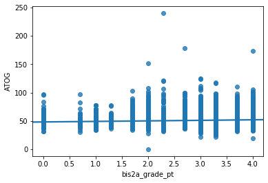

```python
#plt.scatter(main_file['bis2a_grade_pt'],main_file['ATOG'])
sns.regplot(main_file['bis2a_grade_pt'],main_file['ATOG'])
```

First we will make the model for BIS 2A grade. I need to determine which predictors are important.

```python
# 'bis2a_grade_pt',
#  'chem2a_grade_pt',
#  'mat16a_grade_pt',
#  'mat21a_grade_pt',

#For bis2a
y_bis=main_file['bis2a_grade_pt']
mod_bis = sm.OLS(y_bis, X.astype(float), missing='drop',hasconst=True)    # Describe model
res_bis = mod_bis.fit(cov_type='HC0')       # Fit model
print(res_bis.summary())   # Summarize model
```

```
                            OLS Regression Results
==============================================================================
Dep. Variable:         bis2a_grade_pt   R-squared:                       0.262
Model:                            OLS   Adj. R-squared:                  0.253
Method:                 Least Squares   F-statistic:                     28.03
Date:                Thu, 23 Apr 2020   Prob (F-statistic):          3.98e-121
Time:                        14:26:59   Log-Likelihood:                -2745.7
No. Observations:                2305   AIC:                             5547.
Df Residuals:                    2277   BIC:                             5708.
Df Model:                          27
Covariance Type:                  HC0
================================================================================================
                                   coef    std err          z      P>|z|      [0.025      0.975]
------------------------------------------------------------------------------------------------
ATOG                             0.0011      0.006      0.187      0.852      -0.010       0.013
ATOGA                           -0.0258      0.010     -2.530      0.011      -0.046      -0.006
ATOGB                            0.0017      0.011      0.157      0.876      -0.020       0.023
ATOGC                           -0.0066      0.010     -0.682      0.495      -0.026       0.012
ATOGD                            0.0274      0.008      3.285      0.001       0.011       0.044
ATOGE                           -0.0042      0.010     -0.433      0.665      -0.023       0.015
ATOGF                           -0.0021      0.007     -0.283      0.777      -0.017       0.012
ATOGG                           -0.0118      0.007     -1.635      0.102      -0.026       0.002
APTAKEN                          0.0499      0.016      3.072      0.002       0.018       0.082
APPASSED                         0.0499      0.016      3.072      0.002       0.018       0.082
APCREDIT                        -0.0090      0.005     -1.829      0.067      -0.019       0.001
GPA                              0.8002      0.101      7.921      0.000       0.602       0.998
LOWINCOME                        0.0358      0.032      1.115      0.265      -0.027       0.099
SAT_TOTAL_OFFICIAL               0.0019      0.000     10.664      0.000       0.002       0.002
IS_URM                          -0.1289      0.081     -1.596      0.111      -0.287       0.029
ANY_FIRST_TERM_MAJOR_IS_STEM     0.1909      0.052      3.676      0.000       0.089       0.293
STARTED_INTERNATIONAL            0.2110      0.076      2.795      0.005       0.063       0.359
FIRST_GENERATION                -0.0210      0.069     -0.307      0.759      -0.155       0.113
LOW_INCOME                       0.0358      0.032      1.115      0.265      -0.027       0.099
TRIPLE                          -0.1803      0.110     -1.632      0.103      -0.397       0.036
NO_TRIPLE                       -0.0254      0.085     -0.298      0.766      -0.193       0.142
AP_Bio_bool                      0.0920      0.076      1.213      0.225      -0.057       0.241
AP_CS_bool                       0.0648      0.096      0.676      0.499      -0.123       0.253
AP_Chemistry_bool                0.0490      0.064      0.767      0.443      -0.076       0.174
AP_Calculus_AB_bool              0.0170      0.068      0.248      0.804      -0.117       0.151
AP_Calculus_BC_bool             -0.2038      0.108     -1.886      0.059      -0.416       0.008
AP_Physics_bool                 -0.3774      0.148     -2.541      0.011      -0.668      -0.086
AP_Stats_bool                   -0.1815      0.136     -1.331      0.183      -0.449       0.086
SEX_F                           -0.0180      0.038     -0.476      0.634      -0.092       0.056
const                           -3.1067      0.473     -6.568      0.000      -4.034      -2.180
==============================================================================
Omnibus:                      236.383   Durbin-Watson:                   1.984
Prob(Omnibus):                  0.000   Jarque-Bera (JB):              351.452
Skew:                          -0.766   Prob(JB):                     4.82e-77
Kurtosis:                       4.147   Cond. No.                     1.02e+16
==============================================================================

Warnings:
[1] Standard Errors are heteroscedasticity robust (HC0)
[2] The smallest eigenvalue is 3.78e-23. This might indicate that there are
strong multicollinearity problems or that the design matrix is singular.
```

```python
variables = mod_bis.exog
labels = [
'ATOG',
'ATOGA',
'ATOGB',
'ATOGC',
'ATOGD',
'ATOGE',
'ATOGF',
'ATOGG',
'APTAKEN',
'APPASSED',
'APCREDIT',
'GPA',
'LOWINCOME',
'SAT_TOTAL_OFFICIAL',
'IS_URM',
'ANY_FIRST_TERM_MAJOR_IS_STEM',
'STARTED_INTERNATIONAL',
'FIRST_GENERATION',
'LOW_INCOME',
'TRIPLE',
'NO_TRIPLE',
 'AP_Bio_bool',
 'AP_CS_bool',
 'AP_Chemistry_bool',
 'AP_Calculus_AB_bool',
 'AP_Calculus_BC_bool',
'AP_Physics_bool',
 'AP_Stats_bool',
 'SEX_F',
'Constant']
vif = [variance_inflation_factor(variables, i) for i in range(variables.shape[1])]
print(dict(zip(labels, vif)))
```

```
{'ATOG': 6.672677096551358, 'ATOGA': 1.8670029027925314, 'ATOGB': 1.2790531519924873, 'ATOGC': 1.7656209577051727, 'ATOGD': 2.4109718786762464, 'ATOGE': 1.6194288369508556, 'ATOGF': 2.0103792245325214, 'ATOGG': 1.7132366576592053, 'APTAKEN': inf, 'APPASSED': inf, 'APCREDIT': 19.89258649160336, 'GPA'…
```

The lines below are testing for heteroskedasity. I've only recently learned about this test. So it looks like with whites test, there is heteroskedacity In particular, "What you get are two test statistics and two p-values (textbooks prefer the LM test, but the F test is widely used and basically equivalent). Heteroskedasticity is indicated if p <0.05, so according to these tests, this model is heteroskedastic."

```python
white_test = het_white(res_bis.resid,  res_bis.model.exog)
labels = ['LM Statistic', 'LM-Test p-value', 'F-Statistic', 'F-Test p-value']
print(dict(zip(labels, white_test)))
```

```
{'LM Statistic': 405.9466549594376, 'LM-Test p-value': 0.04403863887899495, 'F-Statistic': 1.1581290617954736, 'F-Test p-value': 0.03174571209784337}
```

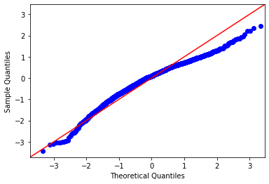

```python
residuals_bis = res_bis.resid # residuals
fig = sm.qqplot(residuals_bis,line='45')
plt.show()
```

Checking leverage v residuals for diagnostics.

```python
# fig_1, ax = plt.subplots(figsize=(12,8))
# fig = sm.graphics.influence_plot(res_bis, ax=ax, criterion="cooks")
```

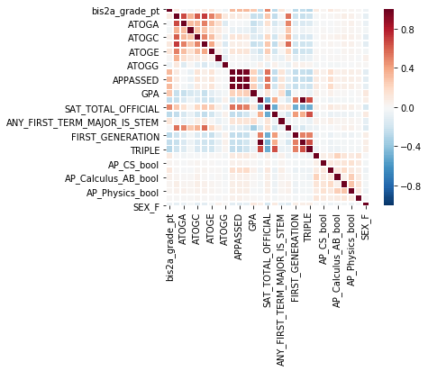

```python
sns.heatmap(main_file[[
    'bis2a_grade_pt',
#  'chem2a_grade_pt',
#  'mat16a_grade_pt',
#  'mat21a_grade_pt',
'ATOG',
'ATOGA',
'ATOGB',
'ATOGC',
'ATOGD',
'ATOGE',
'ATOGF',
'ATOGG',
'APTAKEN',
'APPASSED',
'APCREDIT',
'GPA',
'LOWINCOME',
#'FG',
#'UNWEIGHTED_GPA',
'SAT_TOTAL_OFFICIAL',
'IS_URM',
'ANY_FIRST_TERM_MAJOR_IS_STEM',
'STARTED_INTERNATIONAL',
'FIRST_GENERATION',
'LOW_INCOME',
'TRIPLE',
#'NO_TRIPLE',
# 'AP_Bio',
#  'AP_CS',
#  'AP_Chemistry',
#  'AP_Calculus_AB',
#  'AP_Calculus_BC',
#  'AP_Physics_1',
#  'AP_Physics_2',
#  'AP_Physics_B',
#  'AP_Physics_C_EM',
#  'AP_Physics_C_Mech',
#  'AP_Stats',
 'AP_Bio_bool',
 'AP_CS_bool',
 'AP_Chemistry_bool',
 'AP_Calculus_AB_bool',
 'AP_Calculus_BC_bool',
#  'AP_Physics_1_bool',
#  'AP_Physics_2_bool',
#  'AP_Physics_B_bool',
#  'AP_AP_Physics_C_EM_bool',
 'AP_Physics_bool',
 'AP_Stats_bool',
 'SEX_F']].corr(),
            vmin=-1,
            vmax=1,
            square=True,
            cmap=sns.color_palette("RdBu_r", 100),
            linewidths=.5)
```

Now for the CHEM 2A grade. I need to determine which predictors are important.

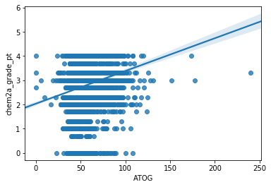

```python
sns.regplot(main_file['ATOG'],main_file['chem2a_grade_pt'])
```

```python
#For chem2a
y_chem=main_file['chem2a_grade_pt']
mod_chem = sm.OLS(y_chem, X.astype(float),missing='drop',hasconst=True)    # Describe model
res_chem = mod_chem.fit(cov_type='HC0')       # Fit model
print(res_chem.summary())   # Summarize model
```

```
                            OLS Regression Results
==============================================================================
Dep. Variable:        chem2a_grade_pt   R-squared:                       0.337
Model:                            OLS   Adj. R-squared:                  0.330
Method:                 Least Squares   F-statistic:                     111.0
Date:                Thu, 23 Apr 2020   Prob (F-statistic):               0.00
Time:                        14:27:01   Log-Likelihood:                -3143.0
No. Observations:                2910   AIC:                             6344.
Df Residuals:                    2881   BIC:                             6517.
Df Model:                          28
Covariance Type:                  HC0
================================================================================================
                                   coef    std err          z      P>|z|      [0.025      0.975]
------------------------------------------------------------------------------------------------
ATOG                             0.0050      0.004      1.295      0.195      -0.003       0.012
ATOGA                           -0.0218      0.008     -2.739      0.006      -0.037      -0.006
ATOGB                            0.0044      0.010      0.464      0.643      -0.014       0.023
ATOGC                            0.0058      0.007      0.800      0.424      -0.008       0.020
ATOGD                            0.0238      0.006      4.007      0.000       0.012       0.035
ATOGE                           -0.0080      0.007     -1.161      0.246      -0.022       0.006
ATOGF                           -0.0053      0.005     -1.019      0.308      -0.016       0.005
ATOGG                           -0.0200      0.005     -3.762      0.000      -0.030      -0.010
APTAKEN                         -0.4340      0.057     -7.638      0.000      -0.545      -0.323
APPASSED                         0.5007      0.064      7.769      0.000       0.374       0.627
APCREDIT                        -0.0060      0.004     -1.525      0.127      -0.014       0.002
GPA                              0.7294      0.070     10.361      0.000       0.591       0.867
LOWINCOME                        0.0034      0.027      0.125      0.900      -0.049       0.056
SAT_TOTAL_OFFICIAL               0.0021      0.000     14.405      0.000       0.002       0.002
IS_URM                          -0.1710      0.056     -3.062      0.002      -0.280      -0.062
ANY_FIRST_TERM_MAJOR_IS_STEM     0.0265      0.039      0.683      0.495      -0.050       0.103
STARTED_INTERNATIONAL            0.2888      0.057      5.051      0.000       0.177       0.401
FIRST_GENERATION                -0.0039      0.051     -0.076      0.939      -0.105       0.097
LOW_INCOME                       0.0034      0.027      0.125      0.900      -0.049       0.056
TRIPLE                          -0.0743      0.082     -0.909      0.363      -0.235       0.086
NO_TRIPLE                       -0.0378      0.066     -0.572      0.568      -0.167       0.092
AP_Bio_bool                     -0.0699      0.067     -1.048      0.295      -0.201       0.061
AP_CS_bool                       0.2801      0.144      1.941      0.052      -0.003       0.563
AP_Chemistry_bool                0.4227      0.047      8.941      0.000       0.330       0.515
AP_Calculus_AB_bool              0.0274      0.057      0.477      0.633      -0.085       0.140
AP_Calculus_BC_bool              0.0433      0.072      0.599      0.549      -0.099       0.185
AP_Physics_bool                  0.0621      0.093      0.665      0.506      -0.121       0.245
AP_Stats_bool                   -0.0065      0.113     -0.058      0.954      -0.227       0.214
SEX_F                           -0.0479      0.028     -1.711      0.087      -0.103       0.007
const                           -3.2446      0.340     -9.553      0.000      -3.910      -2.579
==============================================================================
Omnibus:                      190.886   Durbin-Watson:                   2.009
Prob(Omnibus):                  0.000   Jarque-Bera (JB):              285.199
Skew:                          -0.542   Prob(JB):                     1.17e-62
Kurtosis:                       4.085   Cond. No.                     1.02e+16
==============================================================================

Warnings:
[1] Standard Errors are heteroscedasticity robust (HC0)
[2] The smallest eigenvalue is 4.71e-23. This might indicate that there are
strong multicollinearity problems or that the design matrix is singular.
```

```python
variables = mod_chem.exog
labels = [
'ATOG',
'ATOGA',
'ATOGB',
'ATOGC',
'ATOGD',
'ATOGE',
'ATOGF',
'ATOGG',
'APTAKEN',
'APPASSED',
'APCREDIT',
'GPA',
'LOWINCOME',
'SAT_TOTAL_OFFICIAL',
'IS_URM',
'ANY_FIRST_TERM_MAJOR_IS_STEM',
'STARTED_INTERNATIONAL',
'FIRST_GENERATION',
'LOW_INCOME',
'TRIPLE',
'NO_TRIPLE',
 'AP_Bio_bool',
 'AP_CS_bool',
 'AP_Chemistry_bool',
 'AP_Calculus_AB_bool',
 'AP_Calculus_BC_bool',
'AP_Physics_bool',
 'AP_Stats_bool',
 'SEX_F',
'Constant']
vif = [variance_inflation_factor(variables, i) for i in range(variables.shape[1])]
print(dict(zip(labels, vif)))
```

```
{'ATOG': 7.784740152290912, 'ATOGA': 2.0978891268183673, 'ATOGB': 1.302388495417287, 'ATOGC': 1.905637111497428, 'ATOGD': 2.7171696186161105, 'ATOGE': 1.6400724052400886, 'ATOGF': 1.9758066338236004, 'ATOGG': 1.695072313689037, 'APTAKEN': 13359.092198724456, 'APPASSED': 13384.638692597853, 'APCREDIT…
```

This is the qq-plot to check normality of the residuals

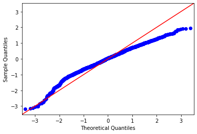

```python
residuals_chem = res_chem.resid # residuals
fig = sm.qqplot(residuals_chem,line='45')
plt.show()
```

```python
# fig, ax = plt.subplots(figsize=(12,8))
# fig = sm.graphics.influence_plot(res_chem, ax=ax, criterion="cooks")
```

Below I created a heat map that shows the correlation between the different variables.

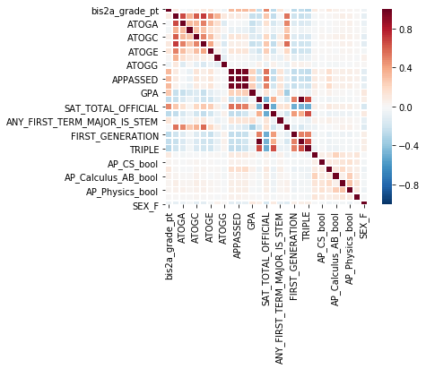

```python
sns.heatmap(main_file[[
    'bis2a_grade_pt',
#  'chem2a_grade_pt',
#  'mat16a_grade_pt',
#  'mat21a_grade_pt',
'ATOG',
'ATOGA',
'ATOGB',
'ATOGC',
'ATOGD',
'ATOGE',
'ATOGF',
'ATOGG',
'APTAKEN',
'APPASSED',
'APCREDIT',
'GPA',
'LOWINCOME',
#'FG',
#'UNWEIGHTED_GPA',
'SAT_TOTAL_OFFICIAL',
'IS_URM',
'ANY_FIRST_TERM_MAJOR_IS_STEM',
'STARTED_INTERNATIONAL',
'FIRST_GENERATION',
'LOW_INCOME',
'TRIPLE',
#'NO_TRIPLE',
# 'AP_Bio',
#  'AP_CS',
#  'AP_Chemistry',
#  'AP_Calculus_AB',
#  'AP_Calculus_BC',
#  'AP_Physics_1',
#  'AP_Physics_2',
#  'AP_Physics_B',
#  'AP_Physics_C_EM',
#  'AP_Physics_C_Mech',
#  'AP_Stats',
 'AP_Bio_bool',
 'AP_CS_bool',
 'AP_Chemistry_bool',
 'AP_Calculus_AB_bool',
 'AP_Calculus_BC_bool',
#  'AP_Physics_1_bool',
#  'AP_Physics_2_bool',
#  'AP_Physics_B_bool',
#  'AP_AP_Physics_C_EM_bool',
 'AP_Physics_bool',
 'AP_Stats_bool',
 'SEX_F']].corr(),
            vmin=-1,
            vmax=1,
            square=True,
            cmap=sns.color_palette("RdBu_r", 100),
            linewidths=.5)
```

```python
#For mat16a
y_mat16 = main_file['mat16a_grade_pt']
mod_mat16 = sm.OLS(y_mat16, X.astype(float),missing='drop',hasconst=True)    # Describe model
res_mat16 = mod_mat16.fit(cov_type='HC0')       # Fit model
print(res_mat16.summary())   # Summarize model
```

```
                            OLS Regression Results
==============================================================================
Dep. Variable:        mat16a_grade_pt   R-squared:                       0.271
Model:                            OLS   Adj. R-squared:                  0.244
Method:                 Least Squares   F-statistic:                     98.86
Date:                Thu, 23 Apr 2020   Prob (F-statistic):          6.05e-215
Time:                        14:27:01   Log-Likelihood:                -917.85
No. Observations:                 758   AIC:                             1892.
Df Residuals:                     730   BIC:                             2021.
Df Model:                          27
Covariance Type:                  HC0
================================================================================================
                                   coef    std err          z      P>|z|      [0.025      0.975]
------------------------------------------------------------------------------------------------
ATOG                            -0.0023      0.008     -0.280      0.779      -0.019       0.014
ATOGA                           -0.0104      0.016     -0.647      0.518      -0.042       0.021
ATOGB                            0.0013      0.025      0.054      0.957      -0.047       0.049
ATOGC                            0.0244      0.014      1.785      0.074      -0.002       0.051
ATOGD                            0.0066      0.013      0.507      0.612      -0.019       0.032
ATOGE                            0.0100      0.012      0.837      0.403      -0.013       0.034
ATOGF                        -2.608e-05      0.011     -0.002      0.998      -0.022       0.022
ATOGG                           -0.0116      0.012     -0.934      0.350      -0.036       0.013
APTAKEN                          0.1195      0.030      3.936      0.000       0.060       0.179
APPASSED                         0.1195      0.030      3.936      0.000       0.060       0.179
APCREDIT                        -0.0343      0.009     -3.634      0.000      -0.053      -0.016
GPA                              1.0680      0.145      7.366      0.000       0.784       1.352
LOWINCOME                        0.0311      0.062      0.504      0.615      -0.090       0.152
SAT_TOTAL_OFFICIAL               0.0021      0.000      6.655      0.000       0.001       0.003
IS_URM                          -0.2826      0.133     -2.125      0.034      -0.543      -0.022
ANY_FIRST_TERM_MAJOR_IS_STEM    -0.0939      0.064     -1.477      0.140      -0.219       0.031
STARTED_INTERNATIONAL            0.3079      0.144      2.142      0.032       0.026       0.590
FIRST_GENERATION                -0.1030      0.122     -0.842      0.400      -0.343       0.137
LOW_INCOME                       0.0311      0.062      0.504      0.615      -0.090       0.152
TRIPLE                           0.1849      0.178      1.038      0.299      -0.164       0.534
NO_TRIPLE                       -0.1349      0.162     -0.833      0.405      -0.452       0.182
AP_Bio_bool                     -0.0756      0.142     -0.533      0.594      -0.353       0.202
AP_CS_bool                       1.3465      0.500      2.691      0.007       0.366       2.327
AP_Chemistry_bool                0.3370      0.255      1.323      0.186      -0.162       0.836
AP_Calculus_AB_bool              0.4191      0.264      1.589      0.112      -0.098       0.936
AP_Calculus_BC_bool             -0.1281      0.198     -0.645      0.519      -0.517       0.261
AP_Physics_bool                 -1.2946      0.276     -4.693      0.000      -1.835      -0.754
AP_Stats_bool                    0.0983      0.446      0.220      0.826      -0.776       0.972
SEX_F                            0.1900      0.072      2.649      0.008       0.049       0.331
const                           -4.2250      0.767     -5.505      0.000      -5.729      -2.721
==============================================================================
Omnibus:                       50.200   Durbin-Watson:                   1.876
Prob(Omnibus):                  0.000   Jarque-Bera (JB):               58.619
Skew:                          -0.649   Prob(JB):                     1.87e-13
Kurtosis:                       3.414   Cond. No.                     1.02e+16
==============================================================================

Warnings:
[1] Standard Errors are heteroscedasticity robust (HC0)
[2] The smallest eigenvalue is 1.13e-23. This might indicate that there are
strong multicollinearity problems or that the design matrix is singular.
```

```python
variables = mod_mat16.exog
labels = [
'ATOG',
'ATOGA',
'ATOGB',
'ATOGC',
'ATOGD',
'ATOGE',
'ATOGF',
'ATOGG',
'APTAKEN',
'APPASSED',
'APCREDIT',
'GPA',
'LOWINCOME',
'SAT_TOTAL_OFFICIAL',
'IS_URM',
'ANY_FIRST_TERM_MAJOR_IS_STEM',
'STARTED_INTERNATIONAL',
'FIRST_GENERATION',
'LOW_INCOME',
'TRIPLE',
'NO_TRIPLE',
 'AP_Bio_bool',
 'AP_CS_bool',
 'AP_Chemistry_bool',
 'AP_Calculus_AB_bool',
 'AP_Calculus_BC_bool',
'AP_Physics_bool',
 'AP_Stats_bool',
 'SEX_F',
'Constant']
vif = [variance_inflation_factor(variables, i) for i in range(variables.shape[1])]
print(dict(zip(labels, vif)))
```

```
{'ATOG': 8.04660387079656, 'ATOGA': 2.2355731363096187, 'ATOGB': 1.4030400889251107, 'ATOGC': 2.1208857717930782, 'ATOGD': 2.18197533443346, 'ATOGE': 1.9320708654630774, 'ATOGF': 2.144002415425904, 'ATOGG': 2.2692334382362986, 'APTAKEN': inf, 'APPASSED': inf, 'APCREDIT': 18.886318544557767, 'GPA': 1…
```

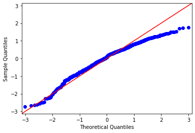

```python
residuals_mat16 = res_mat16.resid # residuals
fig = sm.qqplot(residuals_mat16,line='45')
plt.show()
```

```python
# fig, ax = plt.subplots(figsize=(12,8))
# fig = sm.graphics.influence_plot(res_mat16, ax=ax, criterion="cooks")
```

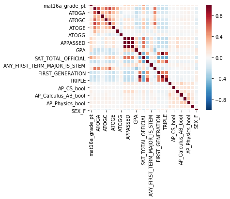

```python
sns.heatmap(main_file[[
#     'bis2a_grade_pt',
#  'chem2a_grade_pt',
 'mat16a_grade_pt',
#  'mat21a_grade_pt',
'ATOG',
'ATOGA',
'ATOGB',
'ATOGC',
'ATOGD',
'ATOGE',
'ATOGF',
'ATOGG',
'APTAKEN',
'APPASSED',
'APCREDIT',
'GPA',
'LOWINCOME',
#'FG',
#'UNWEIGHTED_GPA',
'SAT_TOTAL_OFFICIAL',
'IS_URM',
'ANY_FIRST_TERM_MAJOR_IS_STEM',
'STARTED_INTERNATIONAL',
'FIRST_GENERATION',
'LOW_INCOME',
'TRIPLE',
#'NO_TRIPLE',
# 'AP_Bio',
#  'AP_CS',
#  'AP_Chemistry',
#  'AP_Calculus_AB',
#  'AP_Calculus_BC',
#  'AP_Physics_1',
#  'AP_Physics_2',
#  'AP_Physics_B',
#  'AP_Physics_C_EM',
#  'AP_Physics_C_Mech',
#  'AP_Stats',
 'AP_Bio_bool',
 'AP_CS_bool',
 'AP_Chemistry_bool',
 'AP_Calculus_AB_bool',
 'AP_Calculus_BC_bool',
#  'AP_Physics_1_bool',
#  'AP_Physics_2_bool',
#  'AP_Physics_B_bool',
#  'AP_AP_Physics_C_EM_bool',
 'AP_Physics_bool',
 'AP_Stats_bool',
 'SEX_F']].corr(),
            vmin=-1,
            vmax=1,
            square=True,
            cmap=sns.color_palette("RdBu_r", 100),
            linewidths=.5)
```

```python
#For mat21
y_mat21 = main_file['mat21a_grade_pt']
mod_mat21 = sm.OLS(y_mat21, X.astype(float),missing='drop',hasconst=True)    # Describe model
res_mat21 = mod_mat21.fit(cov_type='HC0')       # Fit model
print(res_mat21.summary())   # Summarize model
```

```
                            OLS Regression Results
==============================================================================
Dep. Variable:        mat21a_grade_pt   R-squared:                       0.176
Model:                            OLS   Adj. R-squared:                  0.156
Method:                 Least Squares   F-statistic:                     9.625
Date:                Thu, 23 Apr 2020   Prob (F-statistic):           2.28e-36
Time:                        14:27:02   Log-Likelihood:                -1435.3
No. Observations:                1146   AIC:                             2929.
Df Residuals:                    1117   BIC:                             3075.
Df Model:                          28
Covariance Type:                  HC0
================================================================================================
                                   coef    std err          z      P>|z|      [0.025      0.975]
------------------------------------------------------------------------------------------------
ATOG                             0.0071      0.007      1.001      0.317      -0.007       0.021
ATOGA                           -0.0137      0.012     -1.185      0.236      -0.036       0.009
ATOGB                            0.0397      0.013      2.984      0.003       0.014       0.066
ATOGC                        -3.307e-05      0.013     -0.003      0.998      -0.025       0.025
ATOGD                            0.0047      0.011      0.438      0.661      -0.016       0.026
ATOGE                           -0.0009      0.013     -0.071      0.944      -0.027       0.025
ATOGF                           -0.0051      0.010     -0.526      0.599      -0.024       0.014
ATOGG                           -0.0208      0.009     -2.259      0.024      -0.039      -0.003
APTAKEN                          0.1114      0.095      1.177      0.239      -0.074       0.297
APPASSED                        -0.0313      0.110     -0.283      0.777      -0.248       0.185
APCREDIT                        -0.0111      0.008     -1.437      0.151      -0.026       0.004
GPA                              0.8396      0.136      6.170      0.000       0.573       1.106
LOWINCOME                       -0.0300      0.053     -0.569      0.569      -0.133       0.073
SAT_TOTAL_OFFICIAL               0.0019      0.000      7.341      0.000       0.001       0.002
IS_URM                          -0.3129      0.109     -2.874      0.004      -0.526      -0.100
ANY_FIRST_TERM_MAJOR_IS_STEM    -0.0949      0.062     -1.522      0.128      -0.217       0.027
STARTED_INTERNATIONAL            0.2431      0.096      2.533      0.011       0.055       0.431
FIRST_GENERATION                 0.0797      0.101      0.793      0.428      -0.117       0.277
LOW_INCOME                      -0.0300      0.053     -0.569      0.569      -0.133       0.073
TRIPLE                           0.1603      0.159      1.007      0.314      -0.152       0.472
NO_TRIPLE                       -0.0714      0.126     -0.565      0.572      -0.319       0.176
AP_Bio_bool                     -0.2393      0.141     -1.700      0.089      -0.515       0.037
AP_CS_bool                       0.7271      0.259      2.809      0.005       0.220       1.234
AP_Chemistry_bool               -0.0321      0.097     -0.330      0.742      -0.223       0.159
AP_Calculus_AB_bool              0.2586      0.111      2.328      0.020       0.041       0.476
AP_Calculus_BC_bool              0.1633      0.196      0.831      0.406      -0.222       0.548
AP_Physics_bool                 -0.1626      0.169     -0.960      0.337      -0.494       0.169
AP_Stats_bool                    0.1705      0.211      0.806      0.420      -0.244       0.585
SEX_F                           -0.0129      0.050     -0.255      0.799      -0.112       0.086
const                           -3.5514      0.693     -5.122      0.000      -4.910      -2.193
==============================================================================
Omnibus:                      111.083   Durbin-Watson:                   1.956
Prob(Omnibus):                  0.000   Jarque-Bera (JB):              155.083
Skew:                          -0.747   Prob(JB):                     2.11e-34
Kurtosis:                       4.008   Cond. No.                     1.02e+16
==============================================================================

Warnings:
[1] Standard Errors are heteroscedasticity robust (HC0)
[2] The smallest eigenvalue is 1.87e-23. This might indicate that there are
strong multicollinearity problems or that the design matrix is singular.
```

```python
variables = mod_mat21.exog
labels = [
'ATOG',
'ATOGA',
'ATOGB',
'ATOGC',
'ATOGD',
'ATOGE',
'ATOGF',
'ATOGG',
'APTAKEN',
'APPASSED',
'APCREDIT',
'GPA',
'LOWINCOME',
'SAT_TOTAL_OFFICIAL',
'IS_URM',
'ANY_FIRST_TERM_MAJOR_IS_STEM',
'STARTED_INTERNATIONAL',
'FIRST_GENERATION',
'LOW_INCOME',
'TRIPLE',
'NO_TRIPLE',
 'AP_Bio_bool',
 'AP_CS_bool',
 'AP_Chemistry_bool',
 'AP_Calculus_AB_bool',
 'AP_Calculus_BC_bool',
'AP_Physics_bool',
 'AP_Stats_bool',
 'SEX_F',
'Constant']
vif = [variance_inflation_factor(variables, i) for i in range(variables.shape[1])]
print(dict(zip(labels, vif)))
```

```
{'ATOG': 8.105935188063992, 'ATOGA': 2.284966713614981, 'ATOGB': 1.259041312745389, 'ATOGC': 1.8407545084277404, 'ATOGD': 3.233090025177202, 'ATOGE': 1.7189191816050742, 'ATOGF': 1.635381289885151, 'ATOGG': 1.5330410603610767, 'APTAKEN': 4849.682393620732, 'APPASSED': 4869.188840915159, 'APCREDIT': …
```

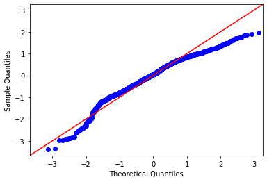

```python
residuals_mat21 = res_mat21.resid # residuals
fig = sm.qqplot(residuals_mat21,line='45')
plt.show()
```

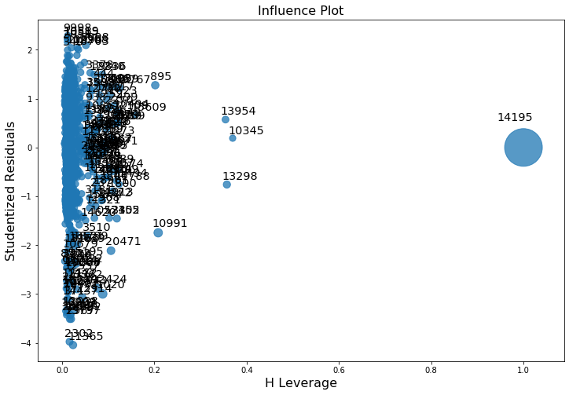

```python
fig, ax = plt.subplots(figsize=(12,8))
fig = sm.graphics.influence_plot(res_mat21, ax=ax, criterion="cooks")
```

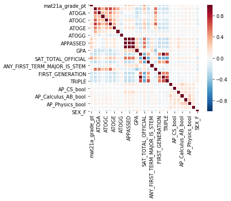

```python
sns.heatmap(main_file[[
#     'bis2a_grade_pt',
#  'chem2a_grade_pt',
#  'mat16a_grade_pt',
 'mat21a_grade_pt',
'ATOG',
'ATOGA',
'ATOGB',
'ATOGC',
'ATOGD',
'ATOGE',
'ATOGF',
'ATOGG',
'APTAKEN',
'APPASSED',
'APCREDIT',
'GPA',
'LOWINCOME',
#'FG',
#'UNWEIGHTED_GPA',
'SAT_TOTAL_OFFICIAL',
'IS_URM',
'ANY_FIRST_TERM_MAJOR_IS_STEM',
'STARTED_INTERNATIONAL',
'FIRST_GENERATION',
'LOW_INCOME',
'TRIPLE',
#'NO_TRIPLE',
# 'AP_Bio',
#  'AP_CS',
#  'AP_Chemistry',
#  'AP_Calculus_AB',
#  'AP_Calculus_BC',
#  'AP_Physics_1',
#  'AP_Physics_2',
#  'AP_Physics_B',
#  'AP_Physics_C_EM',
#  'AP_Physics_C_Mech',
#  'AP_Stats',
 'AP_Bio_bool',
 'AP_CS_bool',
 'AP_Chemistry_bool',
 'AP_Calculus_AB_bool',
 'AP_Calculus_BC_bool',
#  'AP_Physics_1_bool',
#  'AP_Physics_2_bool',
#  'AP_Physics_B_bool',
#  'AP_AP_Physics_C_EM_bool',
 'AP_Physics_bool',
 'AP_Stats_bool',
 'SEX_F']].corr(),
            vmin=-1,
            vmax=1,
            square=True,
            cmap=sns.color_palette("RdBu_r", 100),
            linewidths=.5)
```

```python
# # What features should we keep, or rather whaich are important?
# clf = RandomForestClassifier()
# clf.fit(main_file[controls].dropna(), main_file['chem2a_grade_pt'].dropna())

# # plt.style.use('seaborn-whitegrid')
# # importance = clf.feature_importances_
# # importance = pd.DataFrame(importance, index=dataset_con_enc.drop('predclass', axis=1).columns, columns=["Importance"])
# # importance.sort_values(by='Importance', ascending=True).plot(kind='barh', figsize=(20,len(importance)/2));
```

```python
main_file['chem2a_grade_pt'].describe()
```

```
count    12845.000000
mean         2.721440
std          0.896118
min          0.000000
25%          2.000000
50%          3.000000
75%          3.300000
max          4.000000
Name: chem2a_grade_pt, dtype: float64
```